# Case Study/Project_Multiple Linear Regression: Given below with Used Car data build a machine learning model that can predict Sell Price based on different features ex-Mileage and Age of Cars

# Training And Testing Available Data

We have a dataset containing prices of used BMW cars. We are going to analyze this dataset and build a prediction function that can predict a price by taking mileage and age of the car as input. We will use sklearn train_test_split method to split training and testing dataset

```python
cd C:\Mehul Session\Session 27_Python Introduction\LMS FT\LMS Python\1_Python_Session_File\5_Machine Learning\1_Regression\Session_2\Session_2_A
```

```
C:\Mehul Session\Session 27_Python Introduction\LMS FT\LMS Python\1_Python_Session_File\5_Machine Learning\1_Regression\Session_2\Session_2_A
```

# Import the required libraries for Linear Regression¶

```python
import numpy as np # for data frame
import pandas as pd # for mathemetical operation
import matplotlib.pyplot as plt # for vizualization
%matplotlib inline
import seaborn as sns
from sklearn.linear_model import LinearRegression #  For regression in Machine Learning
from sklearn.metrics import r2_score # For Accuracy
```

```python
cd=('C:/Users/Windows/Downloads')
df=pd.read_csv("carprices.csv")
```

```python
df.head()
```

|  | Mileage | Age(yrs) | Sell Price($) |
| --- | --- | --- | --- |
| 0 | 69000 | 6 | 18000 |
| 1 | 35000 | 3 | 34000 |
| 2 | 57000 | 5 | 26100 |
| 3 | 22500 | 2 | 40000 |
| 4 | 46000 | 4 | 31500 |

```python
#shape function show count of rows and column
df.shape
```

```
(20, 3)
```

# Car Mileage Vs Sell Price

```python
# Columns in dataset
```

```python
df.columns
```

```
Index(['Mileage', 'Age(yrs)', 'Sell Price($)'], dtype='object')
```

```python
# To check linearity btwn Mileage and sales price
```

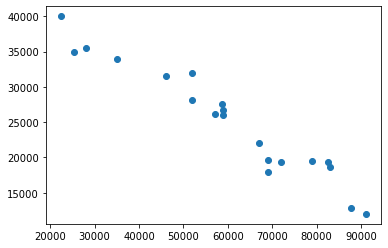

```python
plt.scatter(df['Mileage'],df['Sell Price($)'])
```

```python
# # To check linearity btwn Age and sales price
```

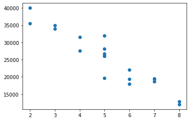

```python
plt.scatter(df['Age(yrs)'],df['Sell Price($)'])
```

# Looking at above two scatter plots, using linear regression model makes sense as we can clearly see a linear relationship between our dependant (i.e. Sell Price) and independant variables (i.e. car age and car mileage)

# Split data in training and testing

The approach we are going to use here is to split available data in two sets

Training: We will train our model on this dataset Testing: We will use this subset to make actual predictions using trained model

The reason we don't use same training set for testing is because our model has seen those samples before, using same samples for making predictions might give us wrong impression about accuracy of our model. It is like you ask same questions in exam paper as you tought the students in the class.

```python
X=df[['Mileage', 'Age(yrs)']]
X
X.shape
```

```
(20, 2)
```

```python
X.head()
```

|  | Mileage | Age(yrs) |
| --- | --- | --- |
| 0 | 69000 | 6 |
| 1 | 35000 | 3 |
| 2 | 57000 | 5 |
| 3 | 22500 | 2 |
| 4 | 46000 | 4 |

```python
Y=df[['Sell Price($)']]
Y
Y.shape
```

```
(20, 1)
```

```python
Y.head()
```

|  | Sell Price($) |
| --- | --- |
| 0 | 18000 |
| 1 | 34000 |
| 2 | 26100 |
| 3 | 40000 |
| 4 | 31500 |